# Plotting Tips

## Different size panels

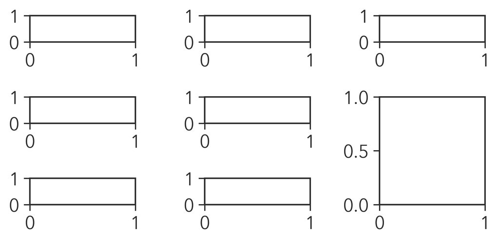

```python
fig7, f7_axs = plt.subplots(ncols=3, nrows=3,figsize=(6,3))
gs = f7_axs[1, 2].get_gridspec()
# remove the underlying axes
for ax in f7_axs[1:, -1]:
    ax.remove()
axbig = fig7.add_subplot(gs[1:, -1])

fig7.tight_layout()
```

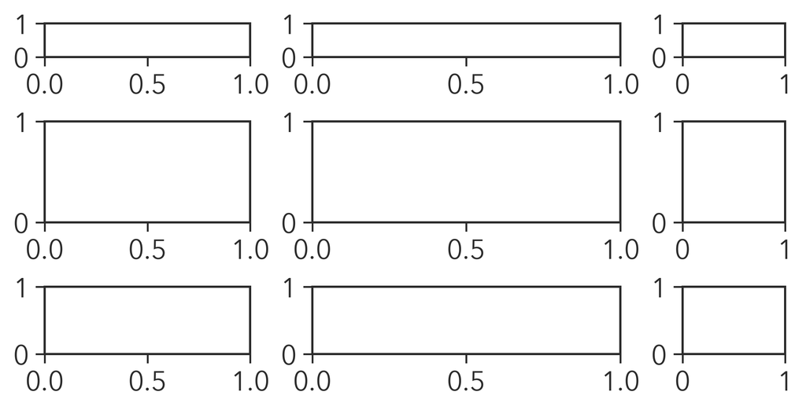

```python
widths = [2, 3, 1]
heights = [1, 3, 2]
#gs_kw = dict(width_ratios=widths, height_ratios=heights)
fig6, f6_axes = plt.subplots(ncols=3, nrows=3, figsize=(6,3), constrained_layout=True,gridspec_kw={'width_ratios':widths, 'height_ratios':heights}) #or gridspec_kw=gs_kw
```

## Mixed cartesian and Polar plots

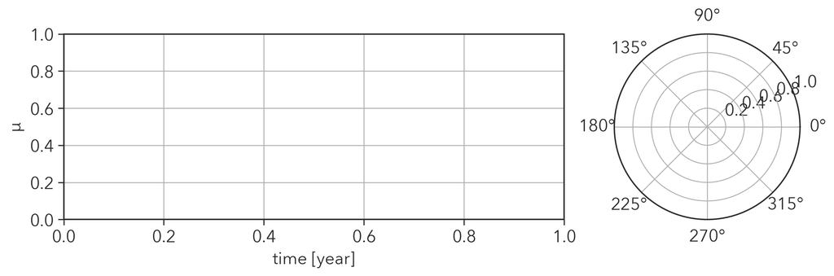

```python
### read the H number distribution ###
r =np.linspace(0, 70,100)
th=np.linspace(0,360,200,endpoint=True)/180*np.pi
R,Th=np.meshgrid(r,th)

### plot figure ###
#fig,ax=plt.subplots(nrows=2,figsize=(10,12))
fig=plt.figure(figsize=(12,3),dpi=120)

#plt.rcParams['font.size'] = 10

gs=GridSpec(1,3) # 2 rows, 3 columns
gs.update(wspace=0.1) # set the spacing between axes.

ax0=fig.add_subplot(gs[0,0:2]) # First row, first column
ax1=fig.add_subplot(gs[0,2], polar=True) # First row, second column


#fig.add_subplot(121)
#ax0.plot(mu,label='monthly')
#ax0.plot(mu.rolling("8760D").mean(),label='24 year')
#ax0.legend()
ax0.grid()
ax0.set_xlabel('time [year]')
ax0.set_ylabel(r'$\mu$')
#ax0.set_xlim(mu.index[154],mu.index[634])

#ax=fig.add_subplot(122, polar=True,facecolor='grey')
#CS=ax.pcolormesh(Th,R,data,cmap=plt.cm.get_cmap('coolwarm', 10))
#fig.colorbar(CS, ax=ax,shrink=0.8,ticks=np.linspace(0,0.1,11),label='$n_H$ [cm$^{-3}$]')
#CS=ax1.pcolormesh(Th,R,data2,cmap='coolwarm')
#fig.colorbar(CS, ax=ax1,shrink=1,label='$n_H$ [cm$^{-3}$]')
#ax1.plot(P10rphi[::2000]['phi']-np.pi, P10rphi[::2000]['R'],'k-')
#ax1.plot(V1rphi[::1000]['phi']-np.pi, V1rphi[::1000]['R'],'k-.')
#ax1.plot(V2rphi[::100]['phi']-np.pi, V2rphi[::100]['R'],'k--')
#ax1.grid(False)
#ax.clabel(CS, inline=1, fontsize=10)
#ax.set_yticklabels([])
#ax1.thetagrids([theta * 15 for theta in range(360//15)])
#ax1.set_rmax(70)
#ax1.set_rlabel_position(135/2)
#import matplotlib.text as txt
#ax1.text(177*np.pi/180,60,'P10')
#ax1.text(-10*np.pi/180,60,'V1')
#ax1.text( 30*np.pi/180,60,'V2')
#ax1.text(135/2*np.pi/180,82,'[au]')
#plt.colorbar()
#ax.grid(True)
#cmap = cm.get_cmap('PiYG', 11)    # 11 discrete colors
#ax.set_thetamin(0)
#ax.set_thetamax(180)
#fig.tight_layout()
plt.show()
```

## Scatter points over a line

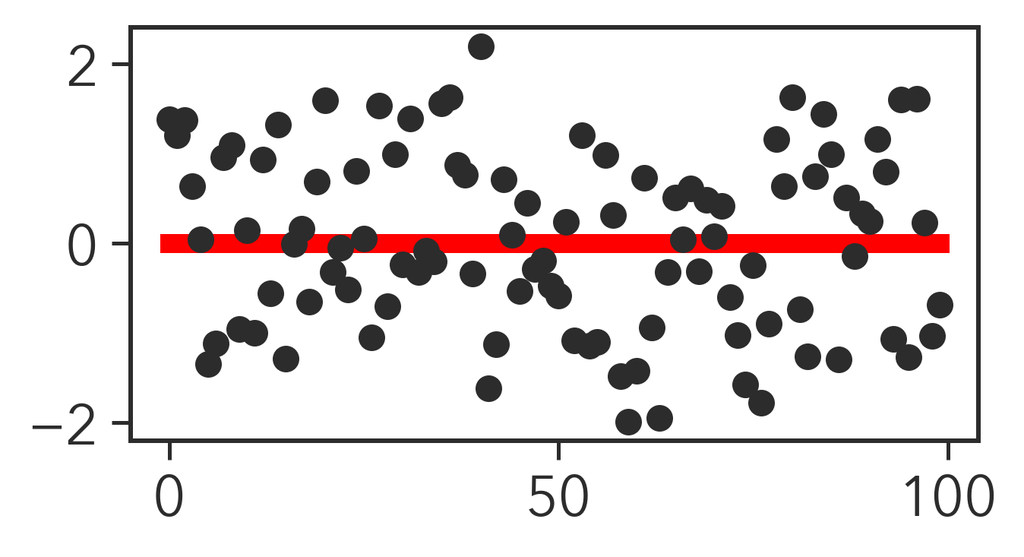

```python
x=np.arange(100)
y=np.random.randn(100)
plt.plot(np.zeros(100), 'red', lw=5)
plt.scatter(x,y, zorder=5)
plt.show()
```

## Subplots including a heatmap and a line plot.

Also setting gridspec_kw and width_ratios, you can adjust the size of figures.

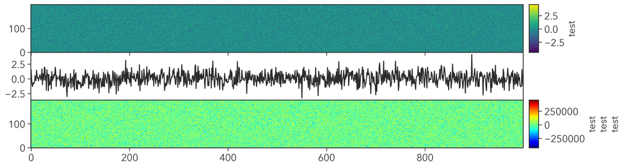

```python
xx=np.linspace(0,100*np.pi,1000)
yy=np.linspace(0,  2*np.pi,1000)
yy=np.cos(xx/4)*np.exp(-xx/100)
XX,YY=np.meshgrid(xx,yy)
ZZ=np.cos(XX/4)*np.exp(-XX/100)

fig, ax = plt.subplots(nrows=3, sharex=True, figsize=(16, 4))
plt.subplots_adjust(hspace=0.)

im0=ax[0].imshow(np.random.randn(200,1000),aspect='auto',origin='lower')
im1=ax[1].plot(np.random.randn(1000))
im2=ax[2].imshow(np.random.randn(200,1000)*1e5,aspect='auto',origin='lower',cmap='jet')

fig.colorbar(im0,ax=ax[0],label='test'            ,aspect=5, pad=0.01)
fig.colorbar(im2,ax=ax[2],label='test\ntest\ntest',aspect=5, pad=0.01)

cb = fig.colorbar(im0,ax=ax[1],aspect=5, pad=0.01)
cb.ax.set_visible(False)

plt.show()
```

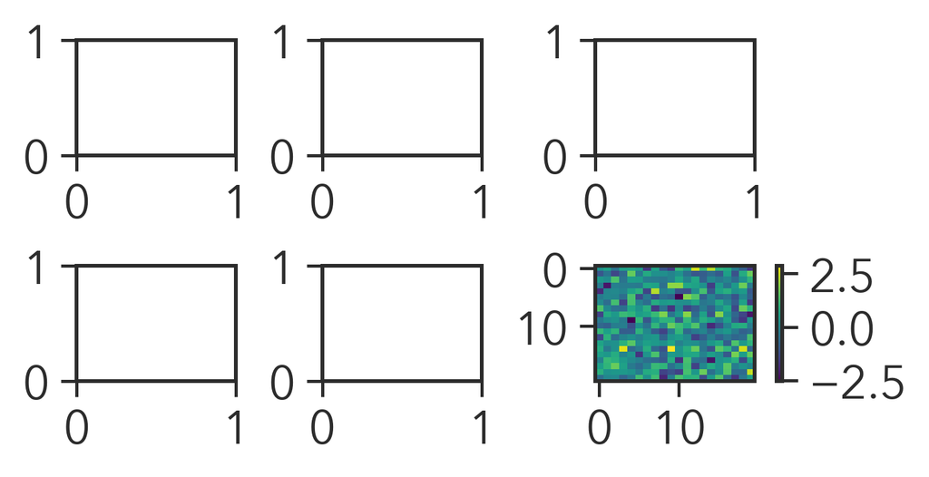

```python
widths = [2, 2, 2]
heights = [1, 1]
gs_kw = dict(width_ratios=widths, height_ratios=heights)
fig, ax = plt.subplots(ncols=3, nrows=2, constrained_layout=True,gridspec_kw=gs_kw)
Z=np.random.randn(20,20)
im1=ax[1,2].imshow(Z, aspect='auto')
fig.colorbar(im1, ax=ax[1,2])
plt.show()
```

## Multiple axes

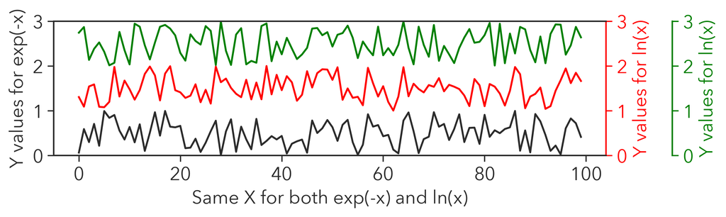

```python
fig,ax=plt.subplots(figsize=(8,2))
ax.plot(np.random.rand(100))
ax.set_ylim(0,3)
ax.set_ylabel('Y values for exp(-x)')
ax.set_xlabel('Same X for both exp(-x) and ln(x)')

ax2=ax.twinx()
ax2.plot(np.random.rand(100)+1,'r')
ax2.set_ylim([0,3])
ax2.set_ylabel('Y values for ln(x)', color='r')
ax2.tick_params(axis='y', colors='r')
ax2.spines["right"].set_edgecolor('r')

ax3=ax.twinx()
ax3.spines["right"].set_position(("axes", 1.12))# move the spine of the second axes outwards
ax3.plot(np.random.rand(100)+2,'g')
ax3.set_ylim(0,3)
ax3.set_ylabel('Y values for ln(x)', color='g')
ax3.tick_params(axis='y', colors='g')
ax3.spines["right"].set_edgecolor('g')

plt.show()
```

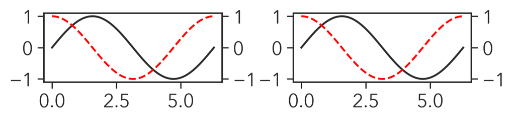

```python
fig,ax=plt.subplots(nrows=1,ncols=2,figsize=(6,1))
plt.subplots_adjust(wspace=0.4,hspace=0.4)
xx=np.linspace(0,2*np.pi,100)

ax[0].plot(xx,np.sin(xx))
ax[1].plot(xx,np.sin(xx))

ax2=np.copy(ax)
for i in range(2):
    ax2[i]=ax[i].twinx()

ax2[0].plot(xx,np.cos(xx),'r--')
ax2[1].plot(xx,np.cos(xx),'r--')

plt.show()
```

## Animation of heatmaps

```python
def update_anim(it):

    fig.clf() #clear the figure

    ax=fig.subplots(2, 2) #add subplots

    fig.tight_layout() #reduce spacing around the figure

    #for i in range(2):
    #    for j in range(2):
    #        ax[i,j].cla()

    Z1=np.random.randn(N,N) #random numbers in 2D
    Z2=np.random.randn(N,N) #random numbers in 2D
    Z3=np.random.randn(N,N) #random numbers in 2D
    Z4=np.random.randn(N,N) #random numbers in 2D

    im1=ax[0,0].imshow(Z1 ,aspect='equal', origin='lower', cmap='Greys')
    im2=ax[1,0].imshow(Z2 ,aspect='equal', origin='lower', cmap='Blues')
    im3=ax[0,1].imshow(Z3 ,aspect='equal', origin='lower', cmap='Reds')
    im4=ax[1,1].imshow(Z4 ,aspect='equal', origin='lower', cmap='Greens')
    #im4=ax[1,1].plot(x,np.sin(it*x))

    cb1=fig.colorbar(im1, ax=ax[0,0])
    cb2=fig.colorbar(im2, ax=ax[1,0])
    cb3=fig.colorbar(im3, ax=ax[0,1])
    cb4=fig.colorbar(im4, ax=ax[1,1])

N=10
nt=10

fig=plt.figure(figsize=(6,6))
anim=animation.FuncAnimation(fig,update_anim,frames=nt)
#plt.subplots_adjust(wspace=0.1,hspace=0.01, bottom=0,top=1)

plt.close()
anim
#anim.save('sample.gif', writer='imagemagick') #save the animation as a gif file
```

[figure not shown]

## Hatched region

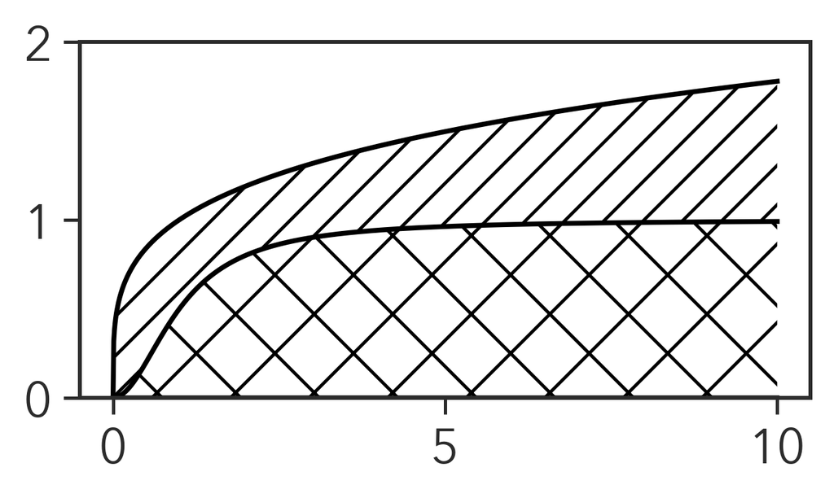

```python
x=np.linspace(0,10,1000)
y1=np.zeros(1000)
y2=x**2/(1+x**2)
y3=x**(1/4)

fig, ax = plt.subplots()
ax.plot(x, y1, "k")
ax.plot(x, y2, "k")
ax.plot(x, y3, "k")

ax.fill_between(x, y1, y2, fc='w', hatch= "x") #{'/', '\\', '|', '-', '+', 'x', 'o', 'O', '.', '*'}
ax.fill_between(x, y2, y3, fc='w', hatch="//")
ax.set_ylim(0,2)

plt.show()
```

## Figure in a figure

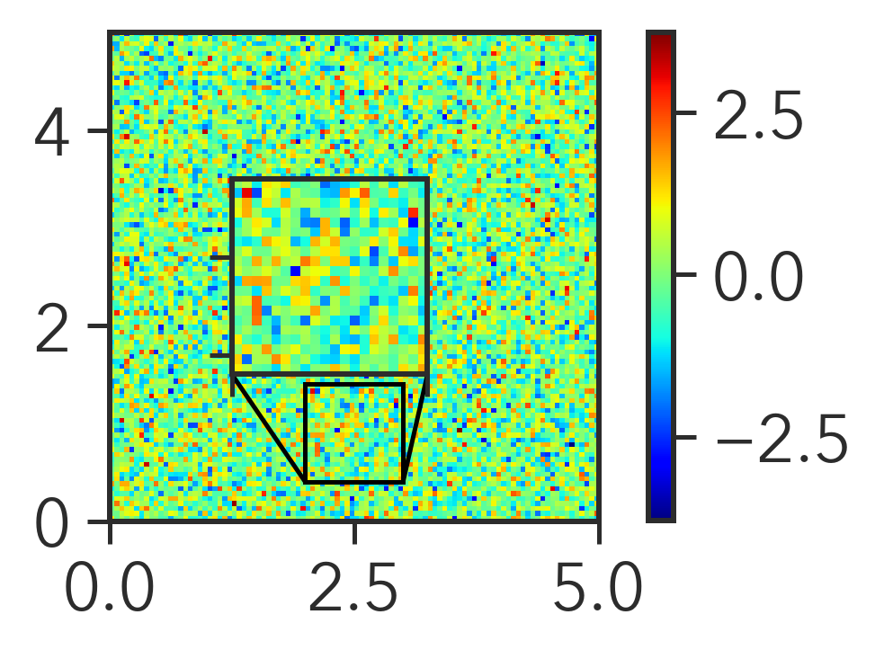

```python
Z = np.random.randn(100,100)

fig = plt.figure()
ax = plt.axes()
plt.imshow(Z, extent=[0, 5, 0, 5], origin='lower',  cmap='jet')
plt.colorbar()

axins = ax.inset_axes([0.25, 0.3, 0.4, 0.4])
axins.imshow(Z, extent=[0, 5, 0, 5], origin="lower",cmap='jet')

# sub region of the original image
x1, x2, y1, y2 = 2, 3, 0.4, 1.4
axins.set_xlim(x1, x2)
axins.set_ylim(y1, y2)
axins.set_xticklabels('')
axins.set_yticklabels('')

#ax.indicate_inset_zoom(axins,ec='red',alpha=1)
mark_inset(ax, axins, loc1=3, loc2=4, fc="none", ec="k",alpha=1)

plt.show()
```

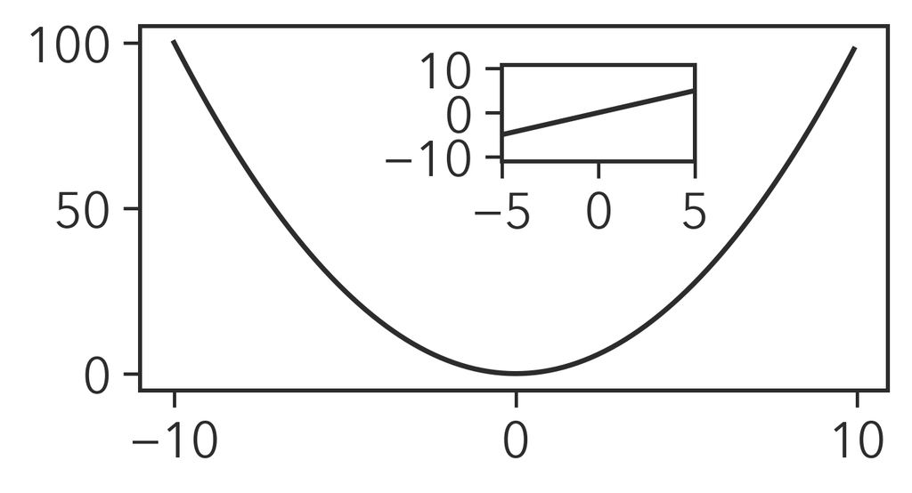

```python
x = np.arange(-10, 10, 0.1)
plt.plot(x, x**2)

ax=plt.axes([0.5, 0.6, 0.2, 0.2])
ax.plot(x, x)
ax.set_xlim(-5,5)

plt.show()
```

## Connect paths over panels

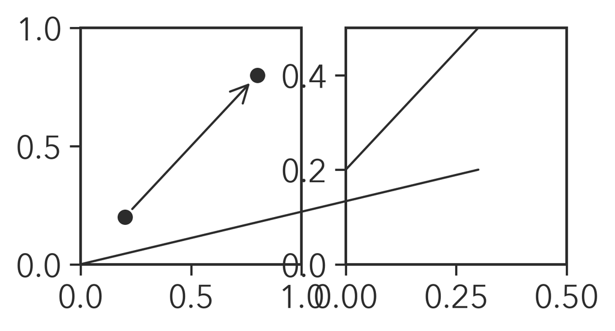

```python
from matplotlib.patches import ConnectionPatch

fig, (ax1, ax2) = plt.subplots(1, 2, figsize=(4, 2))

# Draw a simple arrow between two points in axes coordinates
# within a single axes.
xyA = (0.2, 0.2)
xyB = (0.8, 0.8)
coordsA = "data"
coordsB = "data"
con = ConnectionPatch(xyA, xyB, coordsA, coordsB,
                      arrowstyle="->", shrinkA=5, shrinkB=5,
                      mutation_scale=20, fc="w")
ax1.plot([xyA[0], xyB[0]], [xyA[1], xyB[1]], "o")
ax1.add_artist(con)

# Draw an arrow between the same point in data coordinates,
# but in different axes.
xy = (0.0, 0.0)
coordsA = "data"
coordsB = "data"
con = ConnectionPatch(xyA=(0.3, 0.2), xyB=(0,0), coordsA=coordsA, coordsB=coordsB,
                      axesA=ax2, axesB=ax1,
                      arrowstyle="-", shrinkB=0)
ax2.add_artist(con)

# Draw a line between the different points, defined in different coordinate
# systems.
xyA = (0.6, 1.0)  # in axes coordinates
xyB = (0.0, 0.2)  # x in axes coordinates, y in data coordinates
coordsA = "axes fraction"
coordsB = ax2.get_yaxis_transform()
con = ConnectionPatch(xyA=xyA, xyB=xyB, coordsA=coordsA, coordsB=coordsB,
                      arrowstyle="-")
ax2.add_artist(con)

ax1.set_xlim(0, 1)
ax1.set_ylim(0, 1)
ax2.set_xlim(0, .5)
ax2.set_ylim(0, .5)

plt.show()
```

## Contour plot and colorbar controll

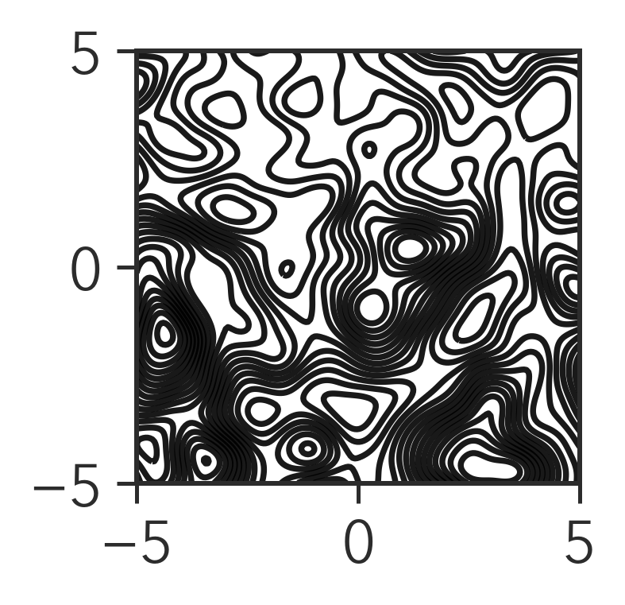

```python
x=np.linspace(-5,5,200)
y=np.linspace(-5,5,200)

X, Y = np.meshgrid(x,y)

nr=2000
cx=-10+20*np.random.rand(nr)
cy=-10 +20*np.random.rand(nr)
k=np.zeros(nr)
for i in range(nr):
    if cx[i]<0: k[i]=1
    if cx[i]>0: k[i]=1

Jz=np.zeros((200,200))
for i in range(nr):
    R=np.sqrt((X-cx[i])**2+(Y-cy[i])**2)
    Jz=Jz+2*k[i]/(1+(k[i]*R)**2)**2

fig,ax = plt.subplots(nrows=1, ncols=1, sharex=True, figsize=(2,2))
im0=ax.contour( X, Y, Jz, levels=20, colors='black',alpha=0.9)
```

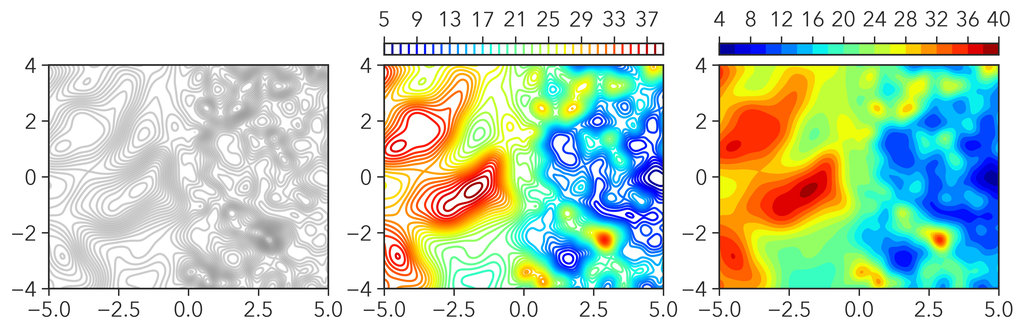

```python
x=np.linspace(-5,5,200)
y=np.linspace(-4,4,200)

X, Y = np.meshgrid(x,y)

nr=1000
cx=-10+20*np.random.rand(nr)
cy=-5 +10*np.random.rand(nr)
k=np.zeros(nr)
for i in range(nr):
    if cx[i]<0: k[i]=1
    if cx[i]>0: k[i]=2

Jz=np.zeros((200,200))
for i in range(nr):
    R=np.sqrt((X-cx[i])**2+(Y-cy[i])**2)
    Jz=Jz+2*k[i]/(1+(k[i]*R)**2)**2

fig,ax = plt.subplots(nrows=1, ncols=3, sharex=True, figsize=(12,4))
im0=ax[0].contour( X, Y, Jz, levels=40, colors='grey',alpha=0.4)
im1=ax[1].contour( X, Y, Jz, levels=40, cmap='jet')
im2=ax[2].contourf(X, Y, Jz, levels=20, cmap='jet')


from mpl_toolkits.axes_grid1.axes_divider import make_axes_locatable

divider = make_axes_locatable(ax[2])
cax = divider.append_axes("top", size="5%", pad=0.1)
cb2=fig.colorbar(im2, cax=cax, ax=ax[2], orientation='horizontal')
cax.xaxis.set_ticks_position('top')

divider1 = make_axes_locatable(ax[1])
cax1 = divider1.append_axes("top", size="5%", pad=0.1)
cb1=fig.colorbar(im1, cax=cax1, ax=ax[1], orientation='horizontal', pad=0.05)
cax1.xaxis.set_ticks_position('top')
#cb1.ax.set_visible(False)

divider0 = make_axes_locatable(ax[0])
cax0 = divider0.append_axes("top", size="5%", pad=0.1)
cb2=fig.colorbar(im0, cax=cax0, ax=ax[0], orientation='horizontal', pad=0.05)
cax0.xaxis.set_ticks_position('top')
cb2.ax.set_visible(False)

#fig.colorbar(im2, cax=cax, ax=ax[1], orientation='horizontal', pad=0.05, anchor=(0.5, 1.0))

for i in range(3):
    ax[i].set_aspect('equal')

plt.show()
```

## Multicolored lines

Actually, there is no easy to plot it. Alternatively, you can use scatter (but points). If you really need multicolored lines, you can check here; [https://matplotlib.org/3.3.3/gallery/lines_bars_and_markers/multicolored_line.html]

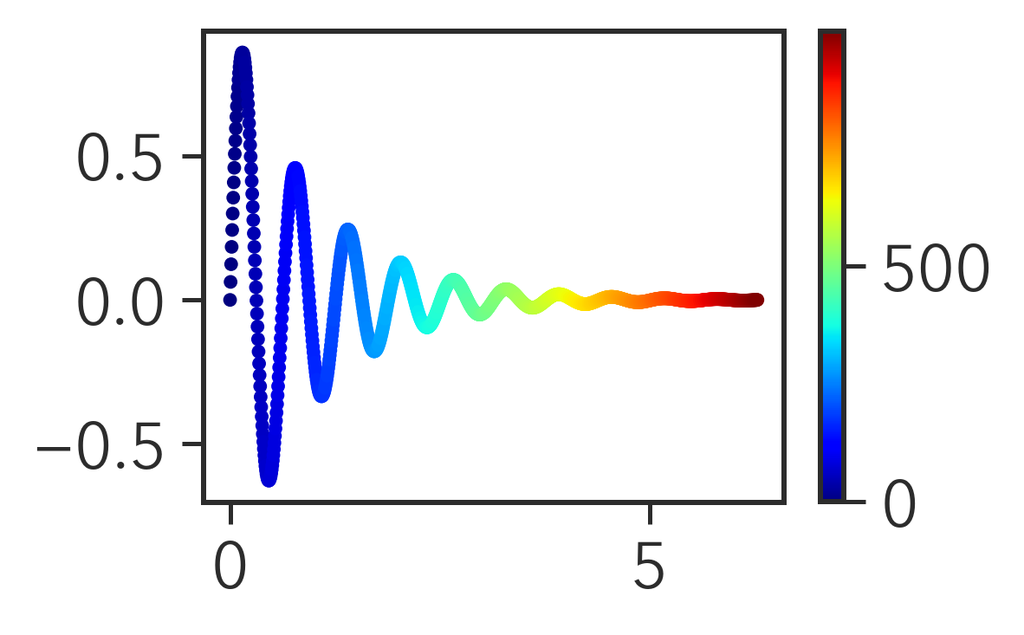

```python
x = np.linspace(0, 2*np.pi, 1000)
y = np.sin(10*x)*np.exp(-x)
z = np.arange(1000)
fig, ax = plt.subplots(figsize=(3,2 ))
im1=ax.scatter(x,y, s=10, c=z, edgecolor='none', cmap='jet')
fig.colorbar(im1, ax=ax)
plt.show()
```

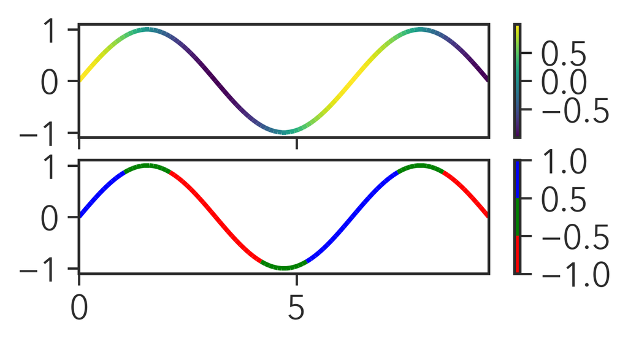

```python
from matplotlib.collections import LineCollection
from matplotlib.colors import ListedColormap, BoundaryNorm

x = np.linspace(0, 3 * np.pi, 100)
y = np.sin(x)
dydx = np.cos(0.5 * (x[:-1] + x[1:]))  # first derivative

# Create a set of line segments so that we can color them individually
# This creates the points as a N x 1 x 2 array so that we can stack points
# together easily to get the segments. The segments array for line collection
# needs to be (numlines) x (points per line) x 2 (for x and y)
points = np.array([x, y]).T.reshape(-1, 1, 2)
segments = np.concatenate([points[:-1], points[1:]], axis=1)

fig, axs = plt.subplots(2, 1, sharex=True, sharey=True)

# Create a continuous norm to map from data points to colors
norm = plt.Normalize(dydx.min(), dydx.max())
lc = LineCollection(segments, cmap='viridis', norm=norm)
# Set the values used for colormapping
lc.set_array(dydx)
lc.set_linewidth(2)
line = axs[0].add_collection(lc)
fig.colorbar(line, ax=axs[0])

# Use a boundary norm instead
cmap = ListedColormap(['r', 'g', 'b'])
norm = BoundaryNorm([-1, -0.5, 0.5, 1], cmap.N)
lc = LineCollection(segments, cmap=cmap, norm=norm)
lc.set_array(dydx)
lc.set_linewidth(2)
line = axs[1].add_collection(lc)
fig.colorbar(line, ax=axs[1])

axs[0].set_xlim(x.min(), x.max())
axs[0].set_ylim(-1.1, 1.1)
plt.show()
```

## Several lines with a colorbar

Reference: https://stackoverflow.com/questions/8342549/matplotlib-add-colorbar-to-a-sequence-of-line-plots

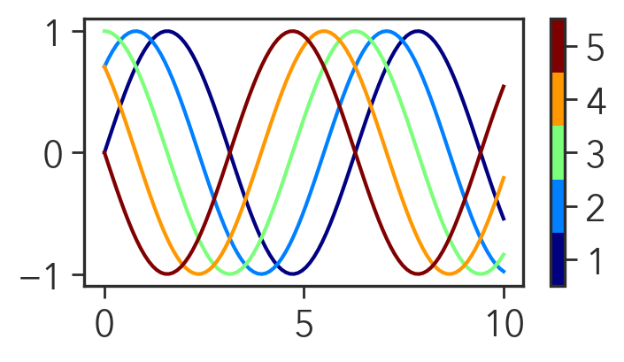

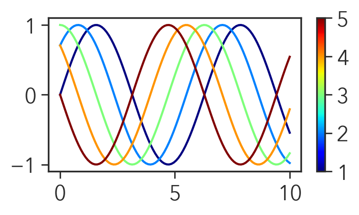

```python
### discrete ###
n_lines = 5
x = np.linspace(0, 10, 100)
y = np.sin(x[:, None] + np.pi * np.linspace(0, 1, n_lines))
c = np.arange(1, n_lines + 1)

#cmap = mpl.cm.get_cmap('jet', n_lines)
#fig, ax = plt.subplots(dpi=100)
## Make dummie mappable
#dummie_cax = ax.scatter(c, c, c=c, cmap=cmap)
## Clear axis
#ax.cla()
#for i, yi in enumerate(y.T):
#    ax.plot(x, yi, c=cmap(i))
#fig.colorbar(dummie_cax, ticks=c)
#plt.show();

cmap = plt.get_cmap("jet", len(c))
norm = mpl.colors.BoundaryNorm(np.arange(len(c)+1)+0.5,len(c))
sm = plt.cm.ScalarMappable(norm=norm, cmap=cmap)
sm.set_array([])  # this line may be ommitted for matplotlib >= 3.1

fig, ax = plt.subplots(dpi=100)
for i, yi in enumerate(y.T):
    ax.plot(x, yi, c=cmap(i))
fig.colorbar(sm, ticks=c)
plt.show()


### continuous ###
n_lines = 5
x = np.linspace(0, 10, 100)
y = np.sin(x[:, None] + np.pi * np.linspace(0, 1, n_lines))
c = np.arange(1, n_lines + 1)

norm = mpl.colors.Normalize(vmin=c.min(), vmax=c.max())
cmap = mpl.cm.ScalarMappable(norm=norm, cmap=mpl.cm.jet)
cmap.set_array([])

fig, ax = plt.subplots(dpi=100)
for i, yi in enumerate(y.T):
    ax.plot(x, yi, c=cmap.to_rgba(i + 1))
fig.colorbar(cmap, ticks=c)
plt.show();
```

## Axis setting

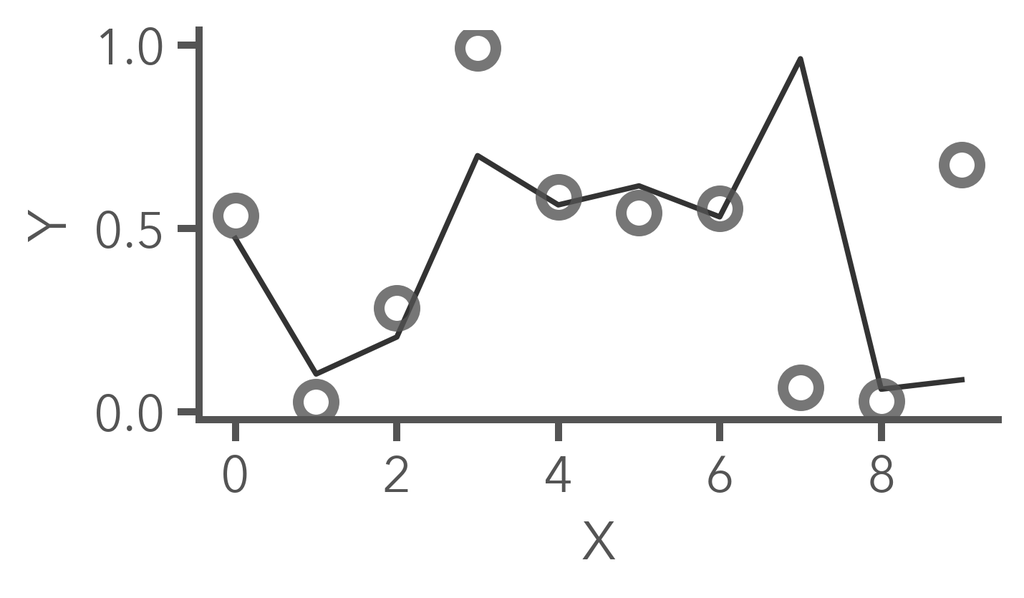

```python
color='#545454'

fig = plt.figure(figsize=(4,2))
ax = fig.add_subplot(111)
ax.plot(np.random.rand(10), 'k', lw=1.5, alpha=0.8)
ax.plot(np.random.rand(10), 'o', color='none', markersize=10, markeredgewidth=3, markeredgecolor=color, alpha=0.8)

ax.spines['top'   ].set_linewidth(0)
ax.spines['right' ].set_linewidth(0)
ax.spines['left'  ].set_linewidth(2)
ax.spines['bottom'].set_linewidth(2)

ax.spines['left'  ].set_color(color)
ax.spines['bottom'].set_color(color)

#ax.spines['right'].set_visible(False)
#ax.spines['left'].set_visible(False)
#ax.spines['top'].set_visible(False)

ax.tick_params(direction='out', length=6, width=2, colors=color, labelsize=14)

#ax.set_xlim(0,370)
#ax.set_ylim(0,105)

#ax.set_xticks([60*i for i in np.arange(7)])
#ax.set_yticks([0, 25, 50, 75, 100])

#ax.set_xticklabels([x for x in np.arange(7)], fontsize=14, color=color)
#ax.set_yticklabels([0,25,50,75, 100]        , fontsize=14, color=color)

#ax.xaxis.label.set_color('red')
#ax.tick_params(axis='x', colors='red')`1

ax.set_xlabel('X', color=color)
ax.set_ylabel('Y', color=color)
#plt.savefig('test.pdf')
plt.show()
```

## Error bar

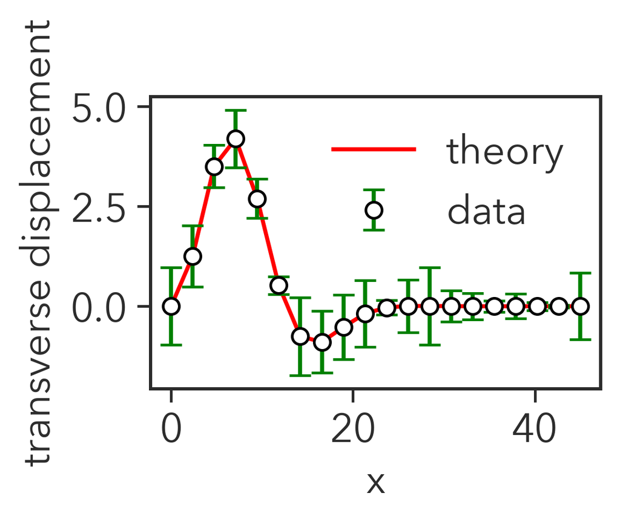

```python
x=np.linspace(0,45,20)
y=x*np.exp(-(x/10.0)**2)*np.sin(x/4)
yerror=np.random.rand(20)

plt.figure(1, figsize = (3,2) )
plt.plot(x, y, 'r-', label="theory")
plt.errorbar(x, y,yerr=yerror,fmt='o', ecolor='green', markeredgecolor = "black", color='w',capsize=4,label="data")
plt.xlabel('x')
plt.ylabel('transverse displacement')
plt.legend(frameon=False,numpoints=1)
#plt.legend(loc='upper right')

plt.show()
```

## Common label

You can use fig.text(). Also you can check here;https://pythonmatplotlibtips.blogspot.com/2017/08/one-ylabel-two-subplots-python-matplotlib-pyplot.html.

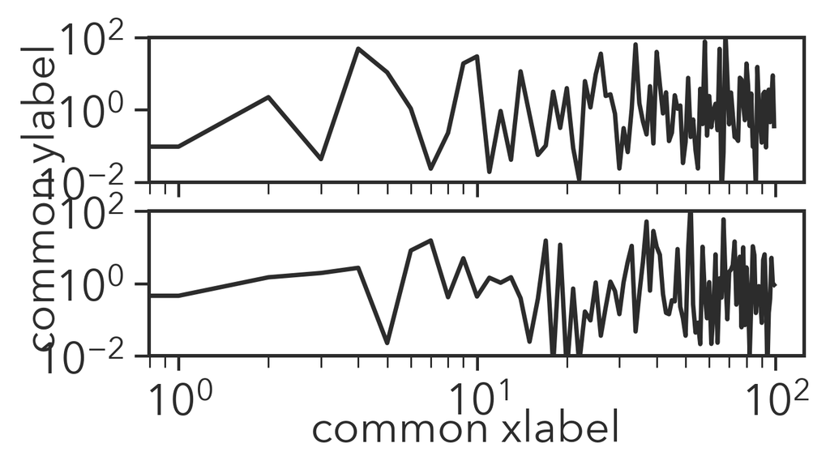

```python
fig,ax = plt.subplots(nrows=2,ncols=1,sharex=True, sharey=True)

ax[0].loglog(10**np.random.randn(100))
ax[1].loglog(10**np.random.randn(100))
ax[1].set_ylim(1e-2,1e2)

# Set common labels
fig.text(0.50,-0.05, 'common xlabel', ha='center', va='center')
fig.text(0.00, 0.50, 'common ylabel', ha='center', va='center', rotation='vertical')

plt.show()
```

## Panel label

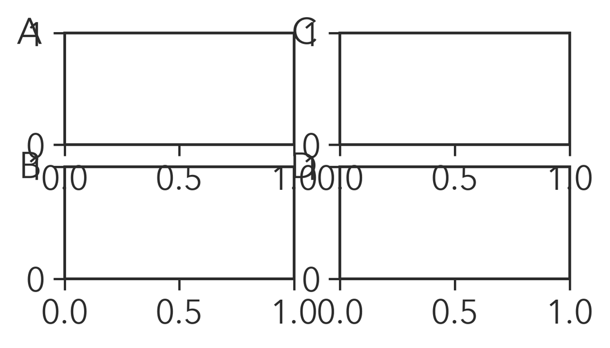

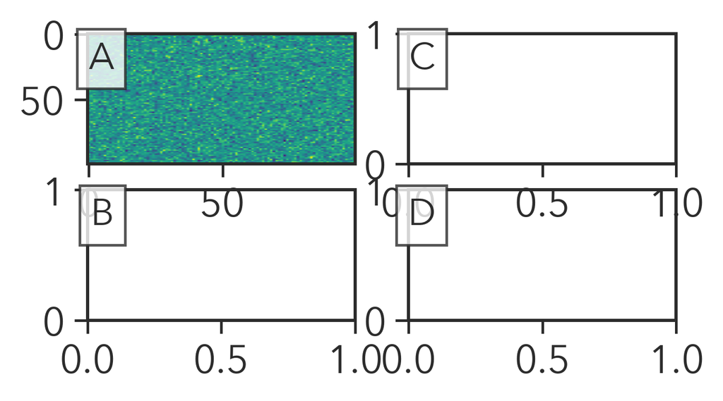

```python
label=[['A', 'B'], ['C', 'D']]

### put panel labels outside ###
fig,ax = plt.subplots(nrows=2, ncols=2)
for i in range(2):
    for j in range(2):
        ax[j,i].text(-0.1, 1.15, label[i][j], transform=ax[j,i].transAxes, fontsize=16, fontweight='bold', va='top', ha='right')
plt.show()
################################

### put panel labels inside with a frame ###
props = dict(boxstyle='square', facecolor='w', alpha=0.8)
fig,ax = plt.subplots(nrows=2, ncols=2)
for i in range(2):
    for j in range(2):
        ax[j,i].text(0.1, 0.95, label[i][j], transform=ax[j,i].transAxes, fontsize=14, fontweight='bold', va='top', ha='right', bbox=props)

ax[0,0].imshow(np.random.randn(100,100), aspect='auto')
plt.show()
```

## Colorbar over several plots

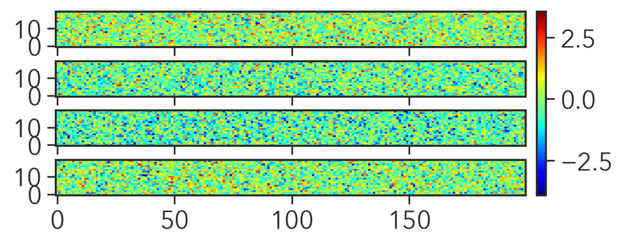

```python
fig, ax = plt.subplots(nrows=4, sharex=True, figsize=(6, 2),dpi=120)
plt.subplots_adjust(hspace=0.4)
im0=ax[0].imshow(np.random.randn(20,200),cmap='jet',origin='lower',aspect='auto')
im1=ax[1].imshow(np.random.randn(20,200),cmap='jet',origin='lower',aspect='auto')
im2=ax[2].imshow(np.random.randn(20,200),cmap='jet',origin='lower',aspect='auto')
im3=ax[3].imshow(np.random.randn(20,200),cmap='jet',origin='lower',aspect='auto')

fig.colorbar(im0,ax=ax[:],pad=0.02)
plt.show()
```

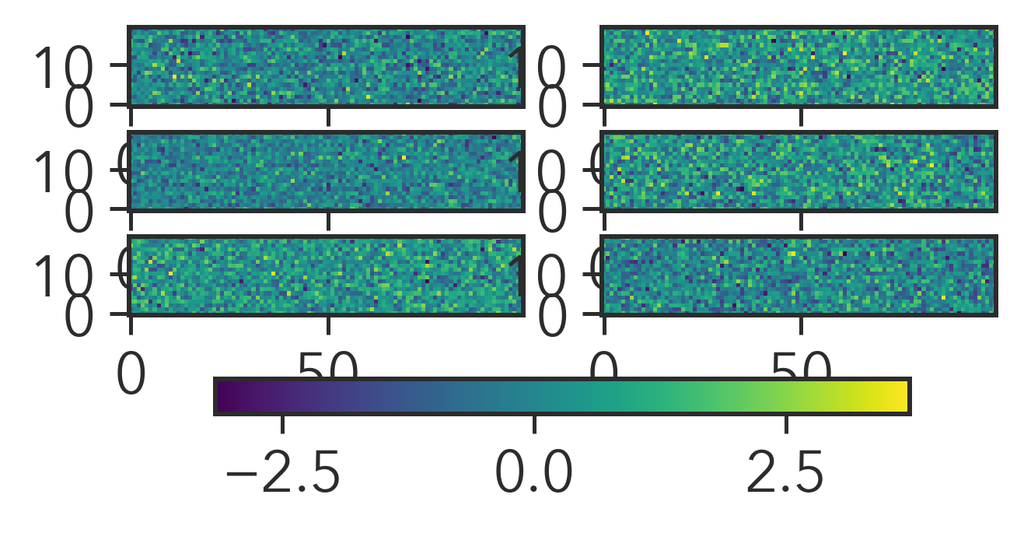

```python
fig,ax=plt.subplots(figsize=(4,2), nrows=3, ncols=2)
#fig.subplots_adjust(wspace=0.1)

im0=ax[0,0].imshow(np.random.randn(20,100), origin='lower', aspect='equal')
im1=ax[1,0].imshow(np.random.randn(20,100), origin='lower', aspect='equal')
im2=ax[2,0].imshow(np.random.randn(20,100), origin='lower', aspect='equal')
im3=ax[0,1].imshow(np.random.randn(20,100), origin='lower', aspect='equal')
im4=ax[1,1].imshow(np.random.randn(20,100), origin='lower', aspect='equal')
im5=ax[2,1].imshow(np.random.randn(20,100), origin='lower', aspect='equal')

cbar=fig.colorbar(im0, ax=ax[:,:], orientation='horizontal', shrink=0.8)
#cbar=fig.colorbar(im0, ax=ax[:,1], orientation='horizontal', shrink=0.6)

plt.show()
```

## Scatter plot with histograms

https://matplotlib.org/3.1.0/gallery/lines_bars_and_markers/scatter_hist.html

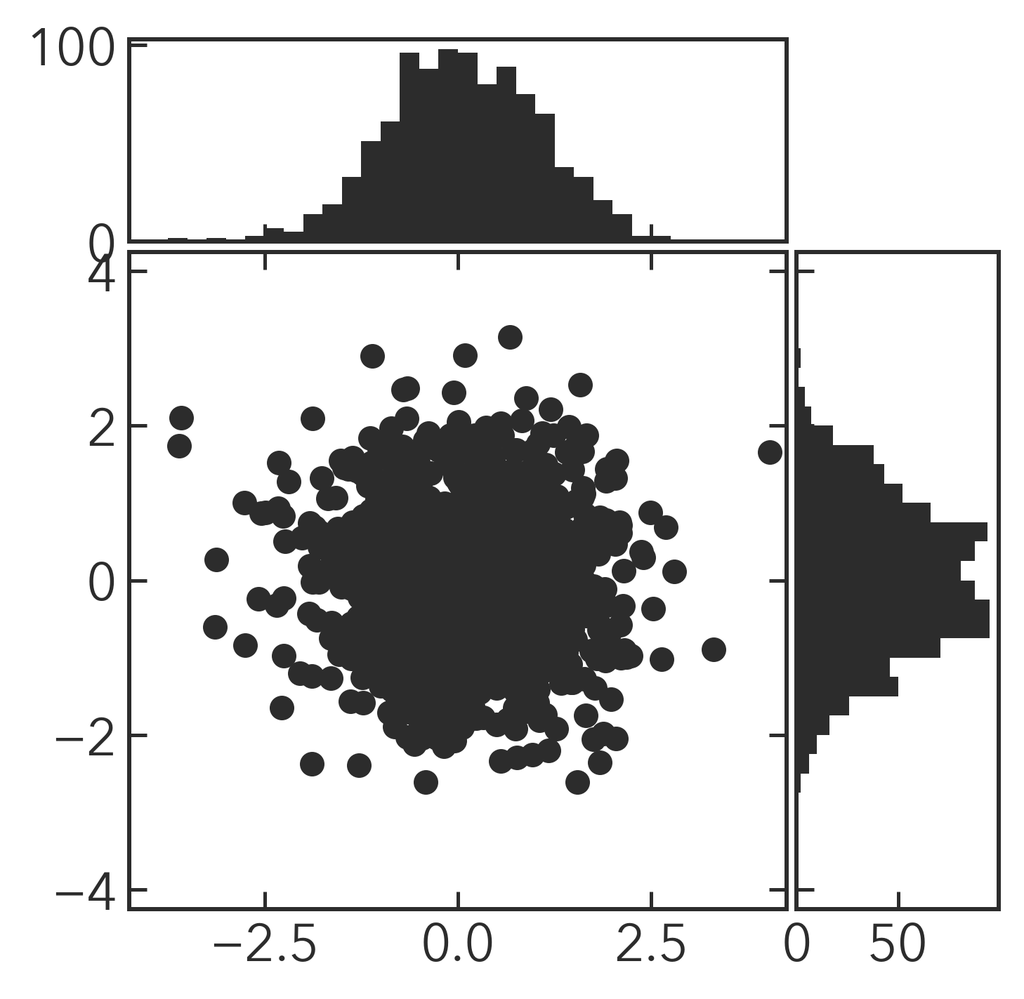

```python
#Fixing random state for reproducibility
np.random.seed(19680801)

# the random data
x = np.random.randn(1000)
y = np.random.randn(1000)

# definitions for the axes
left, width = 0.1, 0.65
bottom, height = 0.1, 0.65
spacing = 0.01

rect_scatter = [left, bottom, width, height]
rect_histx = [left, bottom + height + spacing, width, 0.2]
rect_histy = [left + width + spacing, bottom, 0.2, height]

# start with a rectangular Figure
plt.figure(figsize=(4, 4))

ax_scatr= plt.axes(rect_scatter)
ax_histx= plt.axes(rect_histx)
ax_histy= plt.axes(rect_histy)

ax_scatr.tick_params(direction='in', top=True, right=True)
ax_histy.tick_params(direction='in', labelleft=False)
ax_histx.tick_params(direction='in', labelbottom=False)

# the scatter plot:
ax_scatr.scatter(x, y)
#ax_scatr.hist2d(x,y)

# now determine nice limits by hand:
binwidth = 0.25
lim = np.ceil(np.abs([x, y]).max() / binwidth) * binwidth
ax_scatr.set_xlim((-lim, lim))
ax_scatr.set_ylim((-lim, lim))

bins = np.arange(-lim, lim + binwidth, binwidth)
ax_histx.hist(x, bins=bins)
ax_histy.hist(y, bins=bins, orientation='horizontal')

ax_histx.set_xlim(ax_scatr.get_xlim())
ax_histy.set_ylim(ax_scatr.get_ylim())

plt.show()
```

## Uneven subplots and ticks

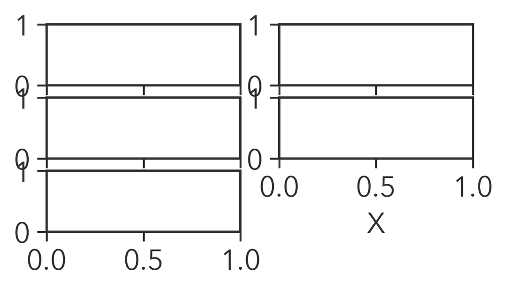

```python
fig, ax = plt.subplots(3,2,sharex=True)
ax[2,1].axis('off') #or fig.delaxes(ax[2,1])
ax[1,1].xaxis.set_tick_params(labelbottom=True)
ax[1,1].set_xlabel('X')
plt.show()
```

## Uneven spacing subplots

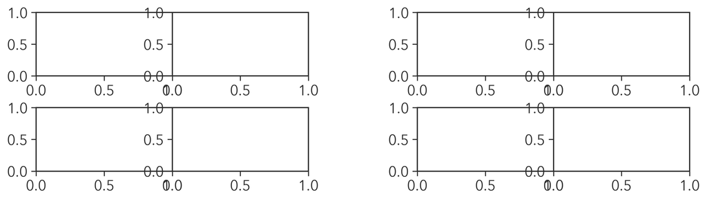

```python
from matplotlib import gridspec

fig = plt.figure(figsize=(12,3))

gs0 = gridspec.GridSpec(2,2, hspace=0.5, wspace=0.4)
gsList = [gridspec.GridSpecFromSubplotSpec(nrows=1,ncols=2, subplot_spec=gs0[i,j], hspace=0, wspace=0) for i in range(2) for j in range(2)]

ax000=fig.add_subplot(gsList[0][0,0])
ax001=fig.add_subplot(gsList[0][0,1])
ax100=fig.add_subplot(gsList[1][0,0])
ax101=fig.add_subplot(gsList[1][0,1])
ax200=fig.add_subplot(gsList[2][0,0])
ax201=fig.add_subplot(gsList[2][0,1])
ax300=fig.add_subplot(gsList[3][0,0])
ax301=fig.add_subplot(gsList[3][0,1])

plt.show()
```

## Bar plot along a trajectory

I'm not sure there is an official way to do this using plt.bar. Here, I use rectangle patches. If the trajectory is just a circle, you may wanna use plt.bar in polar coordinates.

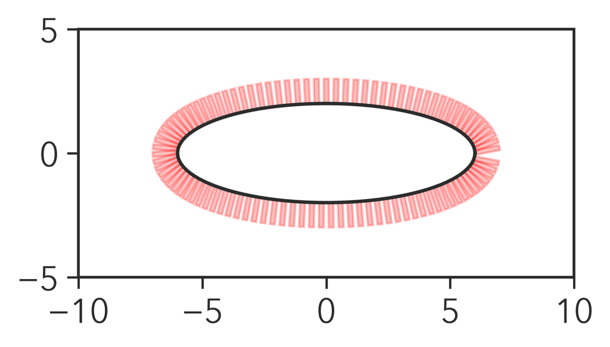

```python
nt=100
tt=np.linspace(0,2*np.pi,nt)
x=6*np.cos(tt)
y=2*np.sin(tt)

fig, ax = plt.subplots(nrows=1,ncols=1)
ax.set_xlim(-10,10)
ax.set_ylim( -5, 5)

ax.plot(x,y)

ax.set_aspect('equal')

### calculate vectors vertical to the orbit ###
angle=np.zeros(nt)
for i in range(1,nt-1):
    a=[x[i-1],y[i-1]]
    b=[x[i+1],y[i+1]]
    angle[i]=np.arccos((b[1]-a[1])/np.sqrt((b[0]-a[0])**2+(b[1]-a[1])**2))
    if (b[0]-a[0])>0: angle[i]=2*np.pi-angle[i]
    angle[i]=angle[i]/np.pi*180-90

### add a rectangle patch ###
height=np.ones(100)
for i in range(1,nt-1):
    rect = patches.Rectangle(xy=(x[i], y[i]), width=0.2, height=height[i], angle=angle[i], color='r', alpha=.25, transform=ax.transData)
    ax.add_patch(rect)

plt.show()
```

## Line plot with space between markers and a line

https://sabopy.com/py/matplotlib-35/

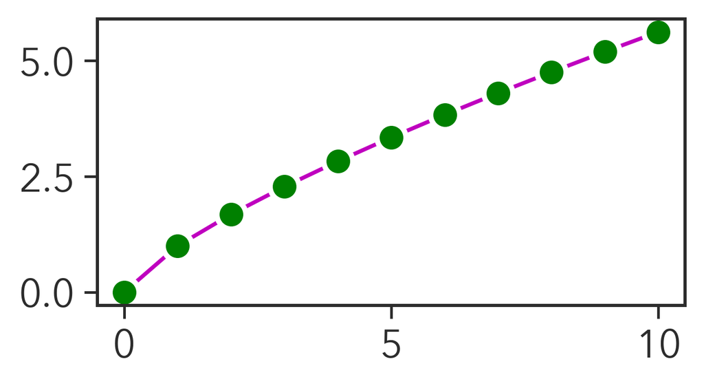

```python
x = np.arange(11)
y = np.arange(11)**(3/4)

# plot
fig=plt.figure(facecolor='w')
plt.plot(x, y, "m")
plt.plot(x, y, 'wo',ms=12)
plt.plot(x, y, 'go',ms=8)
plt.show()
```

## Text watermark

https://matplotlib.org/3.3.3/gallery/text_labels_and_annotations/watermark_text.html#sphx-glr-gallery-text-labels-and-annotations-watermark-text-py

[figure not shown]

```python
fig, ax = plt.subplots()
ax.plot(np.random.rand(20), '-o', ms=8, lw=2, alpha=0.7, mfc='orange')
ax.grid()

ax.text(0.5, 0.5, 'created with matplotlib', transform=ax.transAxes,
        fontsize=30, color='grey', alpha=0.5,
        ha='center', va='center', rotation='-20',zorder=-5)
plt.show()
```

## xkcd-like plot

It's better to wrap plt.xkcd() with a 'with' sentence since xkcd modifies the setting of rcParams.

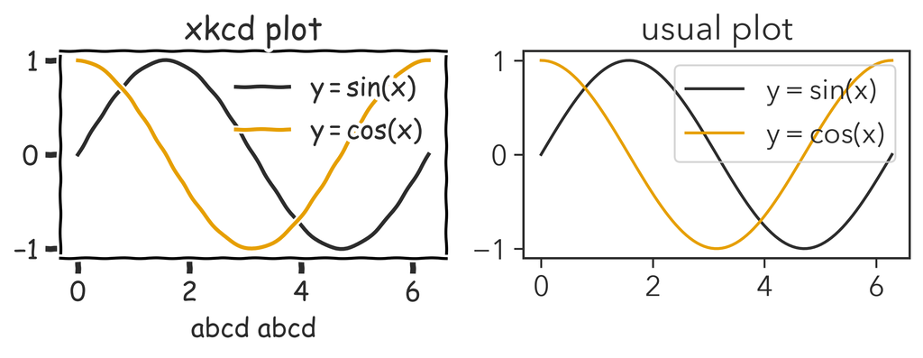

```python
x = np.linspace(0, 2*np.pi, 100)
y1 = np.sin(x)
y2 = np.cos(x)

fig = plt.figure(figsize=(8, 2))
with plt.xkcd():
    ax=fig.add_subplot(1,2,1,title='xkcd plot')
    ax.plot(x, y1, label="$y=sin(x)$")
    ax.plot(x, y2, label="$y=cos(x)$")
    ax.set_xlabel(r'abcd $abcd$')
    ax.legend(frameon=False)

ax=fig.add_subplot(1,2,2,title='usual plot')
ax.plot(x, y1, label="$y=sin(x)$")
ax.plot(x, y2, label="$y=cos(x)$")
ax.legend()

plt.show()
```

## Old-Style Chart

This section is inspired by this post, https://scipython.com/blog/old-style-matplotlib-charts/. Mine is not as authentic as this post... I was looking for a possibility to put noises into 'fig' directory, but I couldn't find a way.

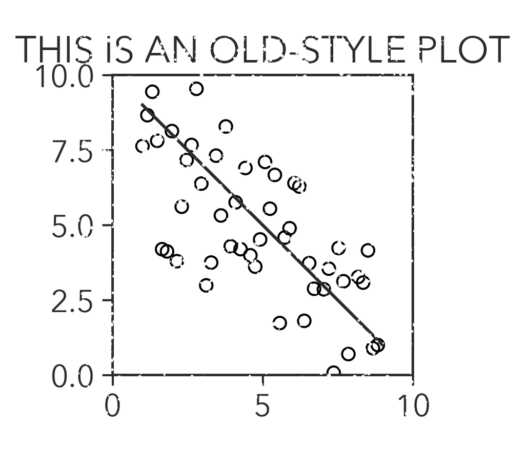

```python
fig=plt.figure(figsize=(4,2),facecolor='w')

ax1=fig.add_axes([0.,0.,1,1], label='cartesian', projection=None)
x=np.linspace(1,9,50)
y=10-x
y_err=10-x+2*np.random.randn(50)
ax1.set_xlim(0,10)
ax1.set_ylim(0,10)
ax1.plot(x,y)
ax1.scatter(x,y_err,ec='k',fc='none')
#ax1.set_xticks([])
#ax1.set_yticks([])
ax1.set_title('THIS IS AN OLD-STYLE PLOT')
ax1.set_aspect('equal')

ax2=fig.add_axes([-0.2,-0.2,1.4,1.4])
x = np.random.rand(3000)
y = np.random.rand(3000)
z = np.random.rand(3000)

for i in np.arange(.1,1.01,.1):
    ax2.scatter(x, y, s=(2*i*(z+.1))**2, ec='none',fc='w', alpha=0.5,zorder=10)

ax2.set_xticks([])
ax2.set_yticks([])
ax2.spines['right' ].set_visible(False)
ax2.spines['left'  ].set_visible(False)
ax2.spines['top'   ].set_visible(False)
ax2.spines['bottom'].set_visible(False)
ax2.set_aspect('equal')
plt.show()
```

## Output this notebook as html file

I use a template answered in this post; https://stackoverflow.com/questions/24062013/how-to-convert-an-ipython-notebook-to-html-with-collapsed-output-and-or-input and tweak as follows. nbconvert=6.0.6 does not work for this template. So you need to downgrade nbconvert.

```python
%%writefile tmp.tpl
{%- extends 'full.tpl' -%}

{% block output_group %}
<div class="output_hidden">
{{ super() }}
</div>
{% endblock output_group %}

{% block input_group -%}
<div class="input_hidden">
{{ super() }}
</div>
{% endblock input_group %}

{%- block input -%}
<div class="in_container">
<div class="in_hidden">
{{ super() }}
<div class="gradient">
</div>
</div>
</div>
{%- endblock input -%}


{%- block header -%}
{{ super() }}

<script src="http://ajax.googleapis.com/ajax/libs/jquery/1.10.2/jquery.min.js"></script>

<style type="text/css">

div.output_wrapper {
margin-top: 0px;
}
.output_hidden {
display: block;
margin-top: 5px;
}
.in_hidden {
 width: 100%;
 overflow: hidden;
 position: relative;
}
.container{
 width: 70% !important;*/
}
.in_container {
  width: 100%;
  margin-left:  0px;
  margin-right:  0px;
  overflow: auto;
}
.gradient {
  width:100%;
  height:3px;
  background:#eeeeee;
  position:absolute;
  bottom:0px;
  left:0;
  display: none;
  opacity: 0.4;
  border-bottom: 2px dashed #000;
}
div.input_prompt {
  color: #178CE3;
  font-weight: bold;
}
div.output_prompt {
  color: rgba(249, 33, 33, 1);
  font-weight: bold;
}


.rendered_html img {
  display: block;
 /* float: left;*/
 margin-left:unset;
  max-height:initial;
text-align:center;
}

</style>

<script>
$(document).ready(function(){
//   $(".output_hidden").click(function(){
//       $(this).prev('.input_hidden').slideToggle();
//   });
//   $(".input_hidden").click(function(){
//       $(this).next('.output_hidden').slideToggle();
//   });
var slideHeight = 25;
$(".in_container").each(function () {
  var $this = $(this);
  var $in_hidden = $this.children(".in_hidden");
  var defHeight  = $in_hidden.height();
  if (defHeight >= 61) {
      var $prompt = $this.prev(".input_prompt");
      var $input_hidden =$this.parents(".input_hidden");
      var $output_hidden = $input_hidden.next(".output_hidden");
      var $gradient = $in_hidden.children(".gradient");
      var $anim_control=$output_hidden.find(".anim-controls")
      $in_hidden.css("height", slideHeight + "px");
      $gradient.css("display", "block");
      $prompt.click(function () {
          var curHeight = $in_hidden.height();
          if (curHeight == slideHeight) {
              $in_hidden.animate({
                  height: defHeight
              }, "normal");
              $gradient.fadeOut();
          }
          else {
              $in_hidden.animate({
                  height: slideHeight
              }, "normal");
              $gradient.fadeIn();
          }
          return false;
      });

      $anim_control.click(function (){
        return false;
       });

      $output_hidden.click(function () {
          var curHeight = $in_hidden.height();
          if (curHeight == slideHeight) {
              $in_hidden.animate({
                  height: defHeight
              }, "normal");
              $gradient.fadeOut();
          }
          else {
              $in_hidden.animate({
                  height: slideHeight
              }, "normal");
              $gradient.fadeIn();
          }
      return false;
      });
  }
});
});

</script>
{%- endblock header -%}
```

```
Writing tmp.tpl
```

```python
%%javascript //save the notebook before output
$("#save-notbook button").trigger('click')
```

```python
!jupyter nbconvert --to html --template tmp.tpl plotting_tips.ipynb
```

```
[NbConvertApp] Converting notebook plotting_tips.ipynb to html
[NbConvertApp] Writing 16389503 bytes to plotting_tips.html
```

```python
!rm tmp.tpl ### erase the temporary template (tmp.tpl)
```

note: 2022/Oct/05 may need to change the version of jinja2

```python
!pip install jinja2==3.0.3
```